# Prova ADS

Renan Pascon

27/06/2021

## Questão 1

Nesta questão analisei primeiramente os dados numa visão geral do Brasil, portanto uni as colunas de consumo somando os consumos para analisar cada tipo individualmente.

### Comércio

O primeiro gráfico um histograma das variáveis para saber como é a distribuição do consumo no comércio. Os valores têm uma distribuição até que uniforme de frequência entre acima de 4000 GWh e abaixo de 8000 GWh, com um pouco mais entre 7000 e 8000

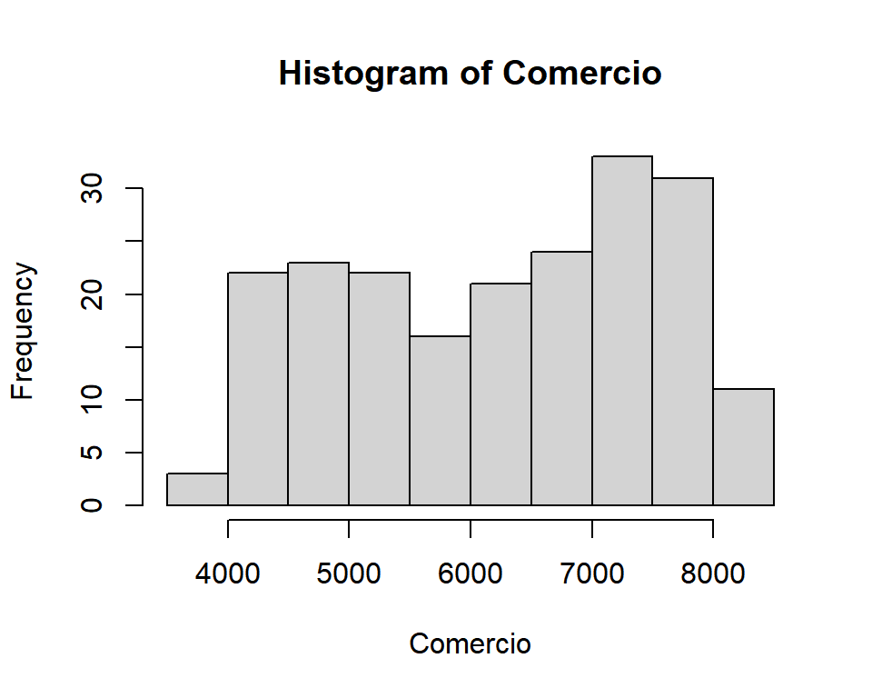

A média do comércio:

```
## [1] 6233.966
```

E o desvio padrão:

```
## [1] 1260.118
```

### Indústria

A indústria tem o maior consumo de todos os três setores com o a maior frequência de consumo em torno de 13500 GWh, e é mais comum pela distribuição os valores serem maiores do que esse valor mais frequente.

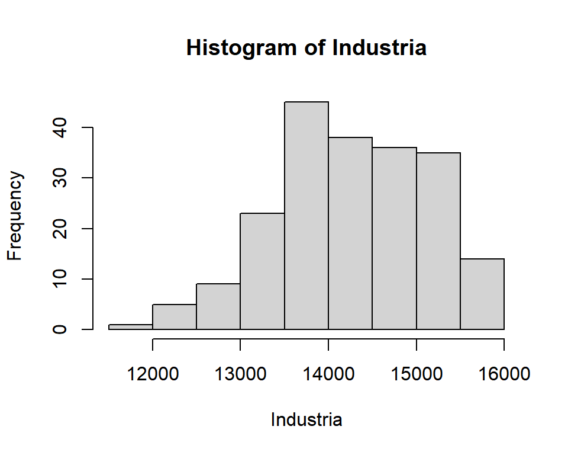

A média da indústria:

```
## [1] 14256.43
```

E o desvio padrão:

```
## [1] 865.9201
```

### Residencial

A partir dessa distrubuição podemos concluir que o consumo residencial é maior do que o do comércio, sendo a indústria a maior consumidora. A distribuição entre os valores de consumo de 6000 GWh e 12000 GWh é praticamente uniforme, porem um pouco maior nos valores de 10000 GWh e 11000 GWh

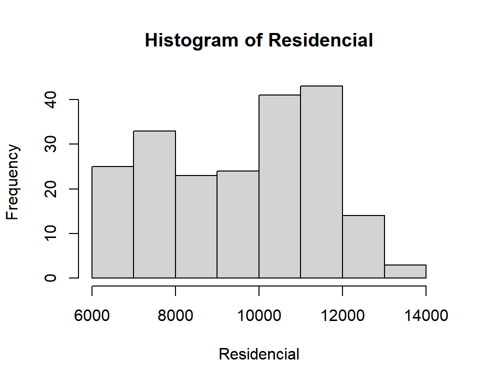

```
## [1] 9608.933
```

E o desvio padrão:

```
## [1] 1908.542
```

### Consumo em relação ao tempo

Decidi então somar as três categorias consumidoras e ver qual é o seu desenvolvimento em relação ao tempo. Podemos observar que o cunsumo se elevou quase que linearmente de 2005 até 2014 aproximadamente e então deu uma leve estabilizada fazendo flutuações com os meses.

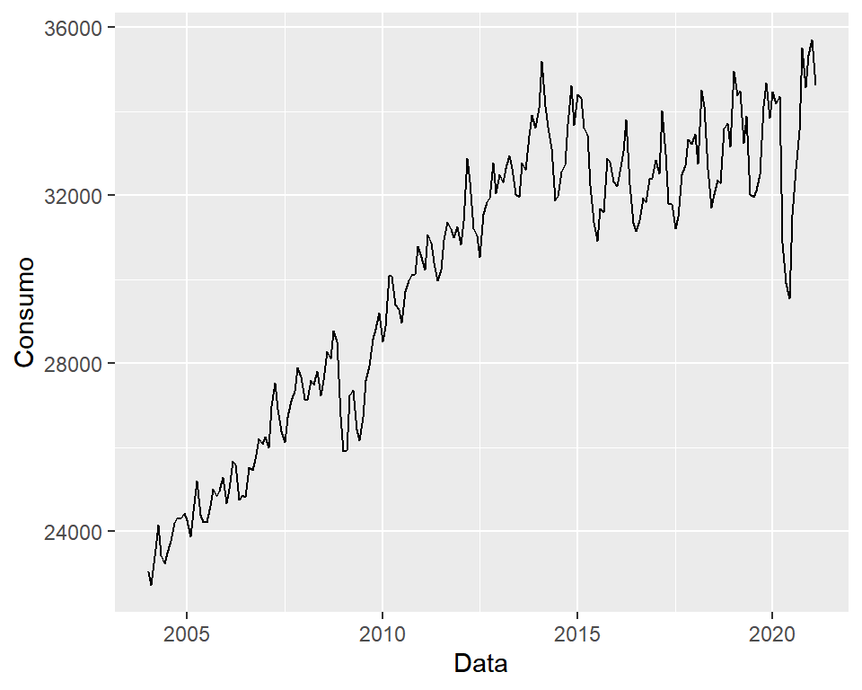

A próxima análise separando os consumos do Brasil podemos ver que o consumo residencial foi o único que continuou subindo, já que de 2015 para frente a industria e comércio não aumentaram o cunsumo levando em consideração as mudanças das estações

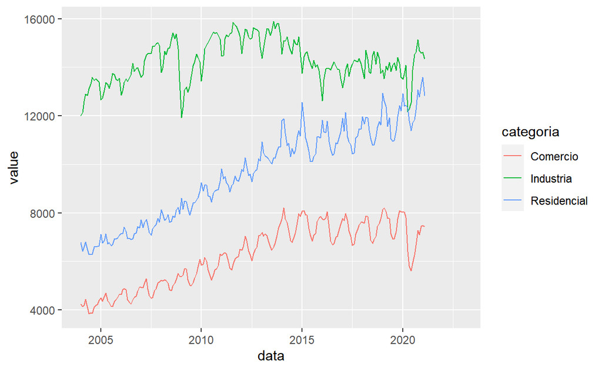

### Variáveis de População e Renda

A variavies de renda podem ser agrupadas juntas para a melhor visualização, elas tem praticamente o mesmo comportamento e coloquei a visualização lado a lado. Aproximadamente a partir de 2014 a renda começão a subir linearmente até 2020 e que comparando cos os valores de consumo total do Brasil aparentemente não revela nenhuma correlação num primeiro momento

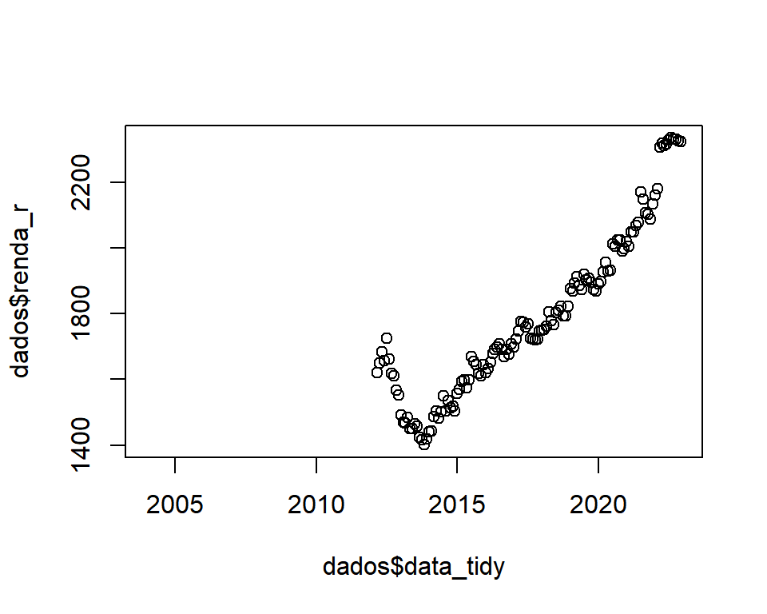

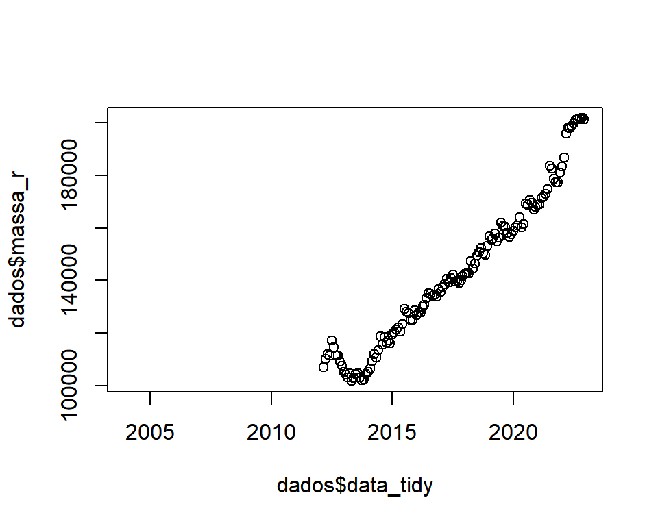

A variável de população Ocupada tem um comportamento similar no crescimento linear de 2005 a 2015 em relação ao total do Brasil.

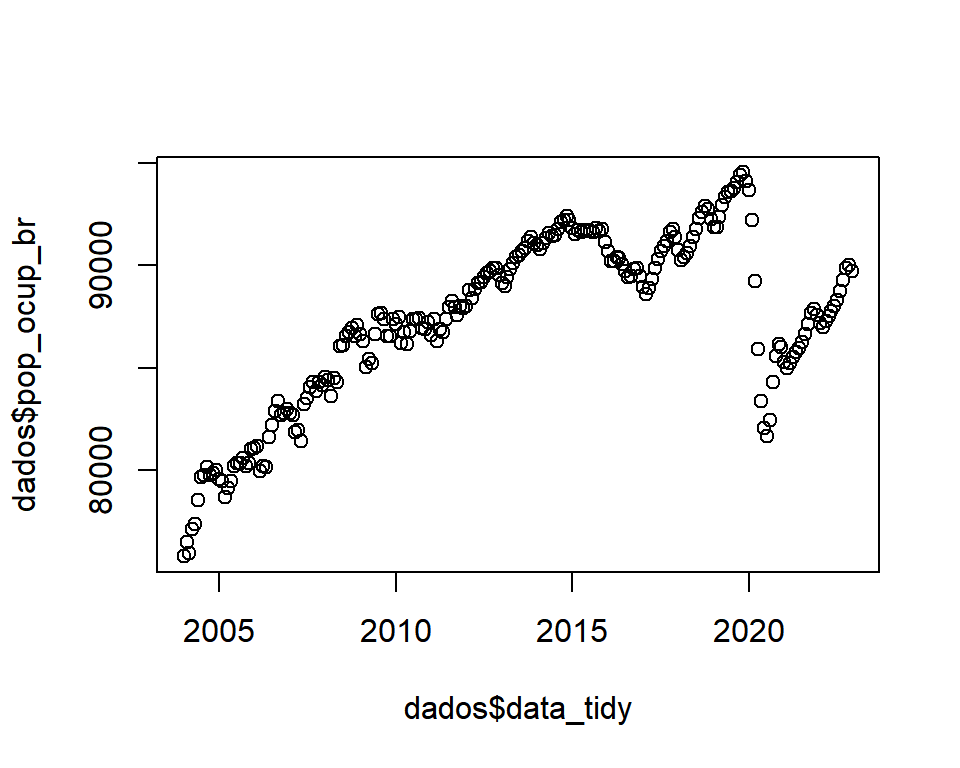

### Índices de Pesquisa Mensal

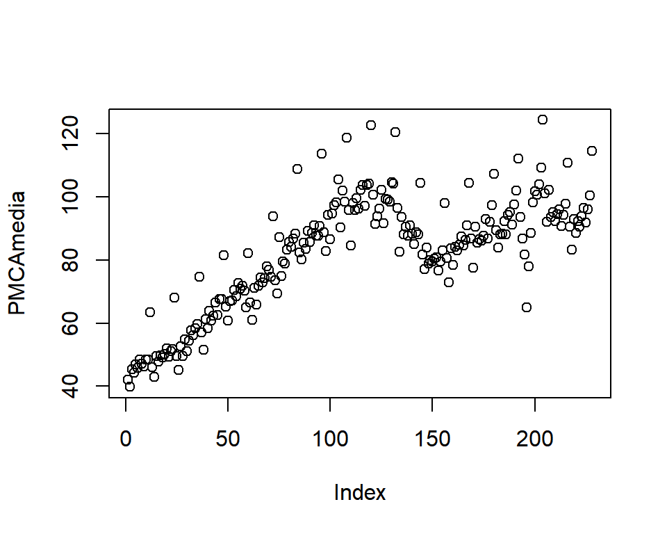

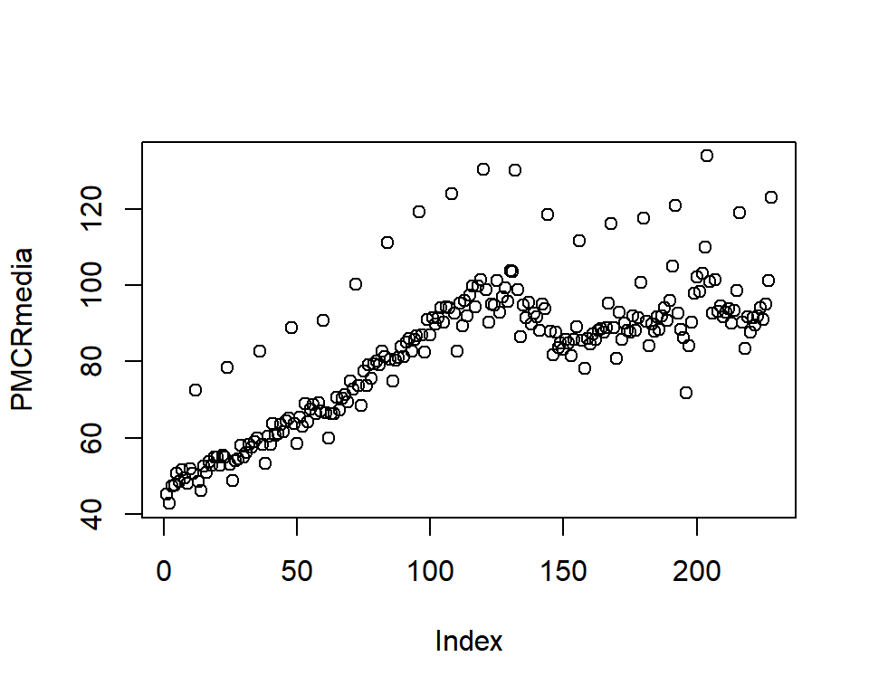

### Correlação entre as variáveis

O próximo passo é verificar as correlações entre as variáveis. A primeira análise das correlações não vou levar em consideração as variáveis de renda, já que não temos os dados até março de 2012.

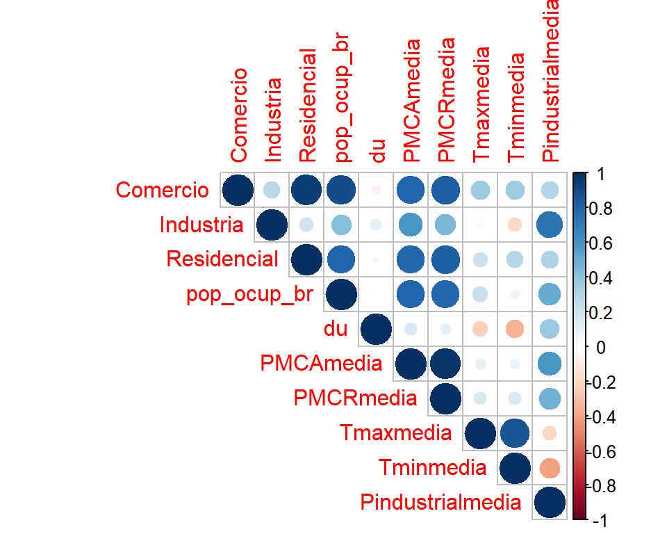

Gerando a matriz de correlações podemos ver que existem algumas variáveis que possuem alta correlação entre elas. O consumo de comércio e residencial tem alta correlação, assim como comércio e população ocupada. As pesquisas de comércio ampla e restrita têm altas correlações com os consumos residenciais e comerciais, assim como a população ocupada. A próxima corelação mais óbvia é a da Produção industrial com o consumo industrial;

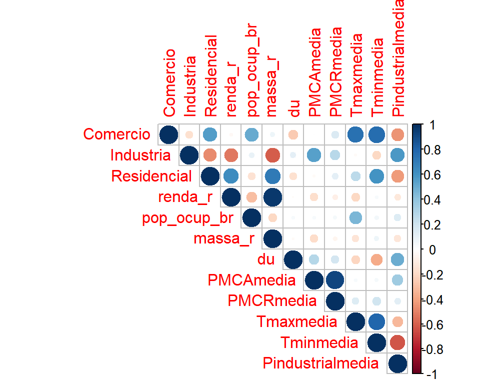

## Questão 2

### Consumo

O Consumo industrial em GWh da região Sudeste pela data

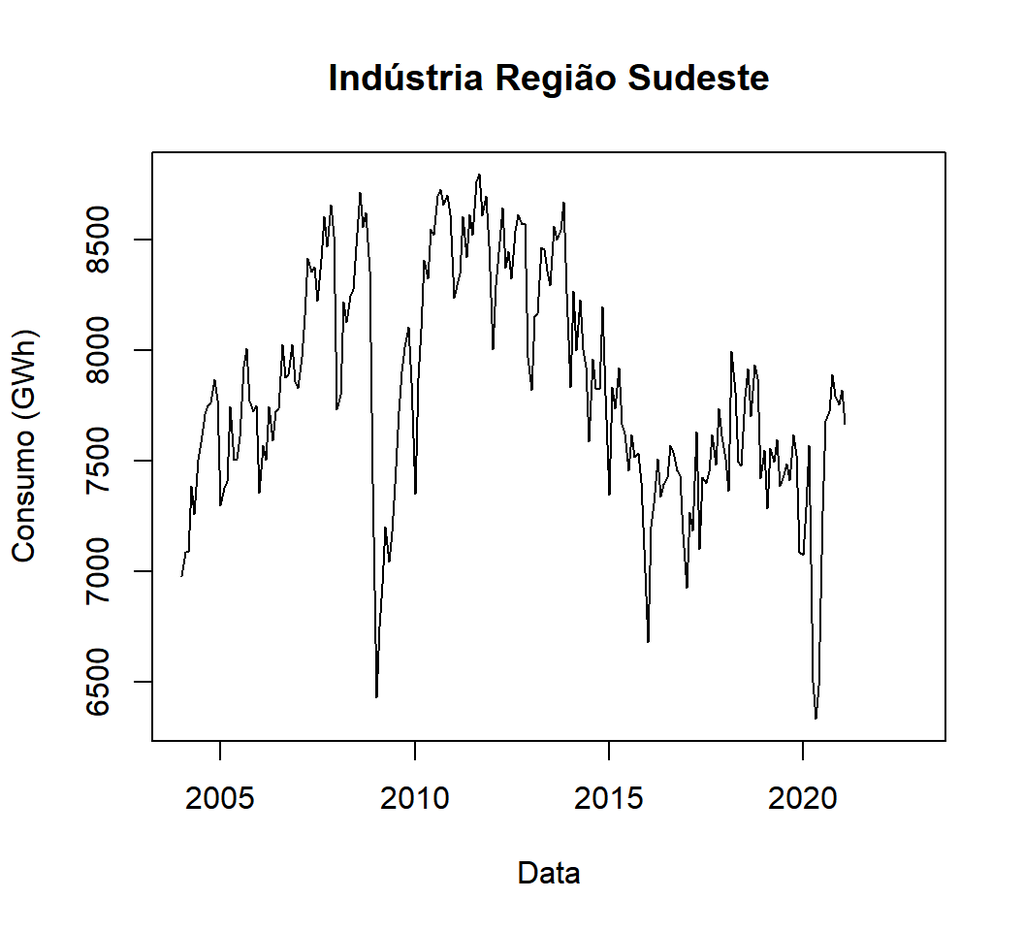

### Correlações

O primeiro passo é filtrar os dados para o sudeste e deixar apenas o consumo da indústria, então plotar as correlações.

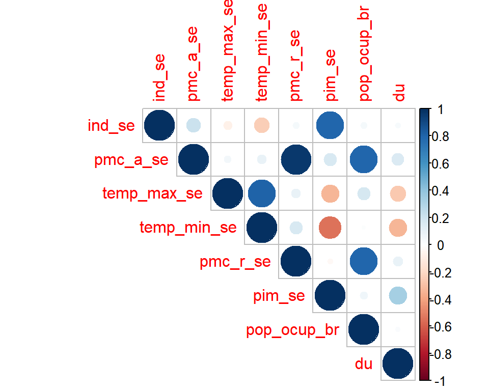

Vamos analisar variável de consumo da indústria em relação as outras variáveis para encontrar as variáveis mais relevantes e possivelmente construir um modelo com as melhores variáveis. A produção industrial é a variável mais óbvia de correlação , também temos uma pequena correlação para a temperatura mínima e a pesquisa ampla.

O próximo passo é verificar o período em que a renda começou a entrar no banco de dados.

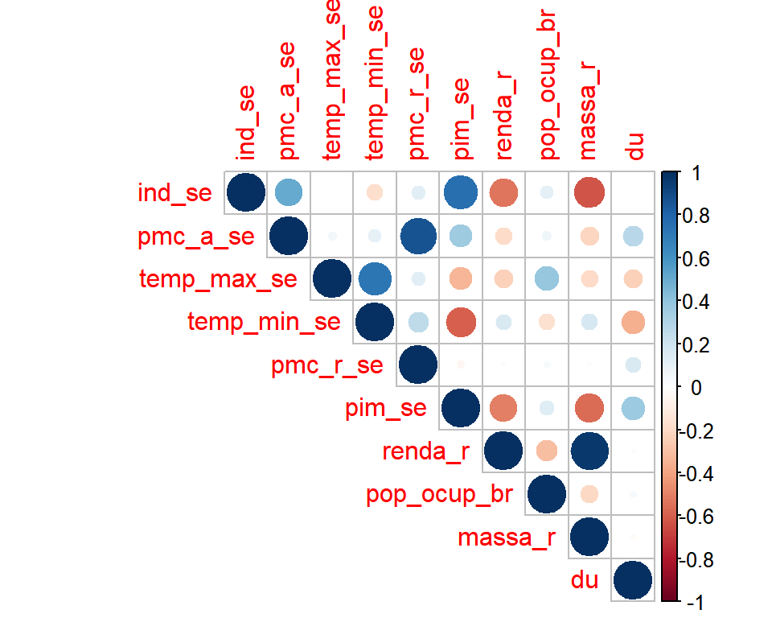

Naturalmente a maior correlação do consumo da indústria vem da produção industrial, mas também as rendas tiveram uma correlação no consumo e um pouco menos a PMCA.

### Modelos

Preparando os dados para treino e teste

```r
##### Previsões
dadosSE_previsao <- dadosSE %>% filter(!is.na(ind_se))  #dados com todos os dados de consumo de industria

# Função para normalizar os dados
normalize <- function(x) {
  return ((x - min(x)) / (max(x) - min(x)))
}

dadosSE_previsao$ind_se_norm <- normalize(dadosSE_previsao$ind_se)
dadosSE_previsao$pim_se_norm <- normalize(dadosSE_previsao$pim_se)

# dividindo os sets

test_index <- createDataPartition(dadosSE_previsao$ind_se_norm, times = 1, p = 0.5, list = FALSE)

train_set <- dadosSE_previsao %>% slice(-test_index)  #train_set
test_set <- dadosSE_previsao %>%  slice(test_index)    #test_set
```

O primeiro modelo será de regressão linear.

```r
fit <- lm(ind_se_norm ~ pim_se_norm, data = train_set)
yPrevisao <- predict(fit,test_set)
sqrt(mean((yPrevisao - test_set$ind_se_norm)^2))
```

```
## [1] 0.1326338
```

```r
fit <- lm(ind_se_norm ~ pim_se_norm +  pmc_a_se + temp_min_se, data = train_set)
yPrevisao <- predict(fit,test_set)
sqrt(mean((yPrevisao - test_set$ind_se_norm)^2))
```

```
## [1] 0.1204428
```

Vamos agora inserir os dados de renda

```r
### Mesma previsão só que com a variavel de renda

dadosSE_renda$ind_se_norm <- normalize(dadosSE_renda$ind_se)
dadosSE_renda$pim_se_norm <- normalize(dadosSE_renda$pim_se)

test_index <- createDataPartition(dadosSE_renda$ind_se_norm, times = 1, p = 0.5, list = FALSE)

train_set <- dadosSE_renda %>% slice(-test_index)  #train_set
test_set <- dadosSE_renda %>%  slice(test_index)    #test_set
```

```r
fit <- lm(ind_se_norm ~ pim_se_norm, data = train_set)
yPrevisao <- predict(fit,test_set)
sqrt(mean((yPrevisao - test_set$ind_se_norm)^2))
```

```
## [1] 0.1479015
```

```r
fit <- lm(ind_se_norm ~ pim_se_norm +  pmc_a_se  + renda_r + massa_r, data = train_set)
yPrevisao <- predict(fit,test_set)
sqrt(mean((yPrevisao - test_set$ind_se_norm)^2))
```

```
## [1] 0.1349651
```

```r
fit <- lm(ind_se_norm ~ pim_se_norm +  pmc_a_se  + renda_r + massa_r + pop_ocup_br + pmc_r_se, data = train_set)
yPrevisao <- predict(fit,test_set)
sqrt(mean((yPrevisao - test_set$ind_se_norm)^2))
```

```
## [1] 0.1314758
```

Modelagem pelos vizinhos mais próximos (KNN)

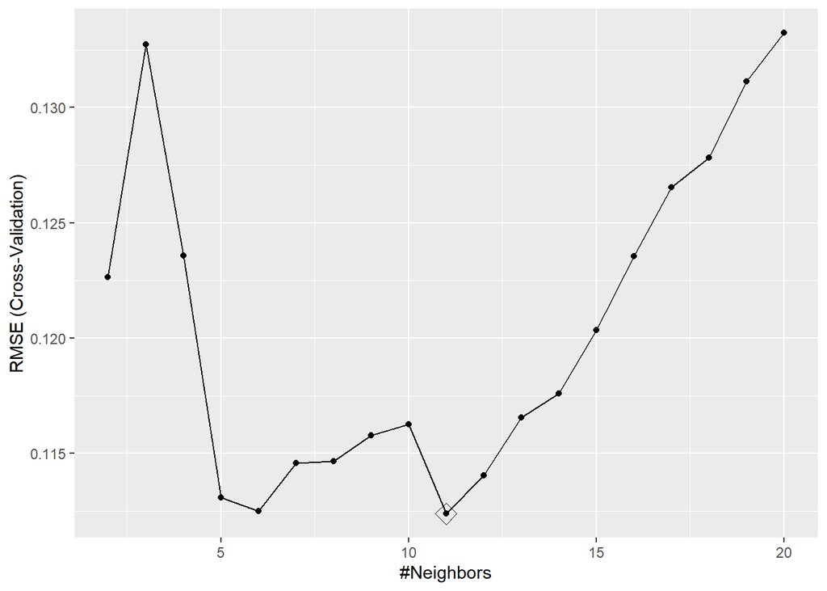

```r
dadosSE_previsao <- dadosSE %>% filter(!is.na(ind_se), !is.na(massa_r))
dadosSE_previsao <- dadosSE_previsao[-1]
dadosSE_previsao$ind_se_norm <- normalize(dadosSE_previsao$ind_se)
dadosSE_previsao <- dadosSE_previsao[-1]

test_index <- createDataPartition(dadosSE_previsao$ind_se_norm, times = 1, p = 0.5, list = FALSE)

train_set <- dadosSE_previsao %>% slice(-test_index)  #train_set
test_set <- dadosSE_previsao %>%  slice(test_index)    #test_set

# KNN
# KNN
col_index <- c(1,5,6,8)   # Colunas das 4 variáveis

control <- trainControl(method = "cv", number = 10, p = .2) # Cross validation pra treinar o knn, 5 variações do train set com porcentagem de 30% de teste

train_knn <- train(train_set[,col_index], train_set$ind_se_norm, method = "knn",
                   tuneGrid = data.frame(k = seq(2, 20, 1)), data = train_set, # valores de 2 a 20 de vizinhos
                   trControl = control)
ggplot(train_knn, highlight = TRUE) # plotando o melhor k para o modelo
```

```r
# Melhor K é

fit_knn <- knn3(train_set[,col_index], factor(train_set$ind_se_norm), k = train_knn$bestTune)

Y_knn <- predict(fit_knn, test_set[,col_index], type = "class")

sqrt(mean((as.numeric(as.character(Y_knn)) - test_set$ind_se_norm)^2))
```

```
## [1] 0.1488053
```

Próximo modelo mais simples sem cross validation e todas as variaveis

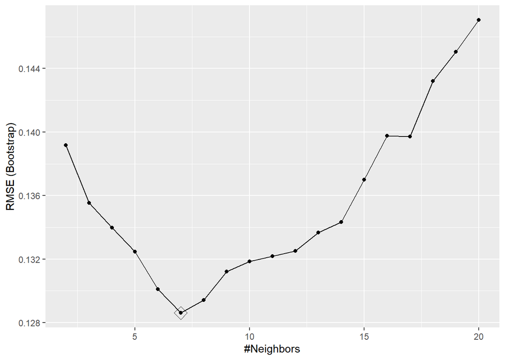

```r
col_index <- (1:(ncol(train_set)-1))

train_knn <- train(train_set[,col_index], train_set$ind_se_norm, method = "knn",
                   tuneGrid = data.frame(k = seq(2, 20, 1)), data = train_set, # valores de 2 a 20 de vizinhosl
                   )
ggplot(train_knn, highlight = TRUE) # plotando o melhor k para o modelo
```

```r
fit_knn <- knn3(train_set[,col_index], factor(train_set$ind_se_norm), k = train_knn$bestTune)

Y_knn <- predict(fit_knn, test_set[,col_index], type = "class")

sqrt(mean((as.numeric(as.character(Y_knn)) - test_set$ind_se_norm)^2))
```

```
## [1] 0.1662192
```

Próximo modelo podemos testar o método de regressão de Loess que demanda um pouco mais de capacidade computacional.Neste método temos 2 parâmetros para testar, o span e o grau.

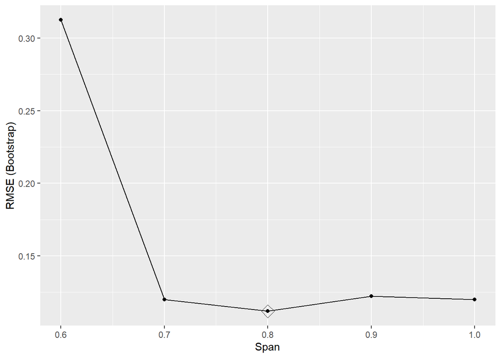

```r
grid <- expand.grid(span = seq(0.6, 1, len = 5), degree = 1)

train_loess <- train(ind_se_norm ~ pim_se + massa_r + pmc_a_se,
                     method = "gamLoess",
                     tuneGrid=grid,
                     data = train_set)
ggplot(train_loess, highlight = TRUE)
```

Próximo Modelo será de random forests, o set de treino será colocado com cross - validation

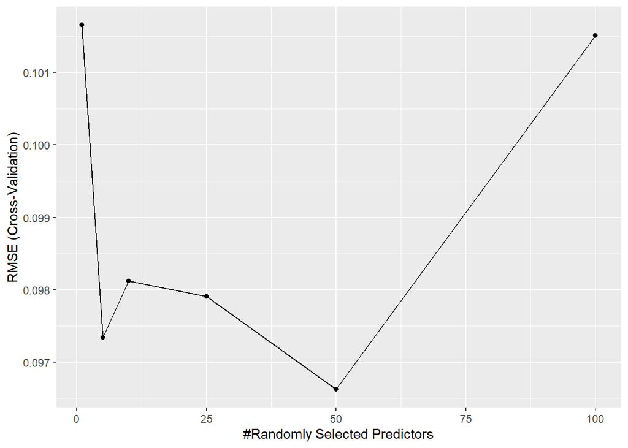

```r
control <- trainControl(method="cv", number = 5)
grid <- data.frame(mtry = c(1, 5, 10, 25, 50, 100))
col_index <- c(1,5,8)   # Colunas das 3 variáveis sem a renda , apenas a massa de renda

train_rf <-  train(train_set[, col_index], train_set$ind_se_norm,
                   method = "rf",
                   ntree = 100,
                   trControl = control,
                   tuneGrid = grid,
                   nSamp = 5000)
ggplot(train_rf)
```

```r
fit_rf <- randomForest(train_set[, col_index], train_set$ind_se_norm,
                       minNode = train_rf$bestTune$mtry)
y_rf <- predict(fit_rf, test_set[ ,col_index])
sqrt(mean((y_rf - test_set$ind_se_norm)^2))
```

```
## [1] 0.1203137
```

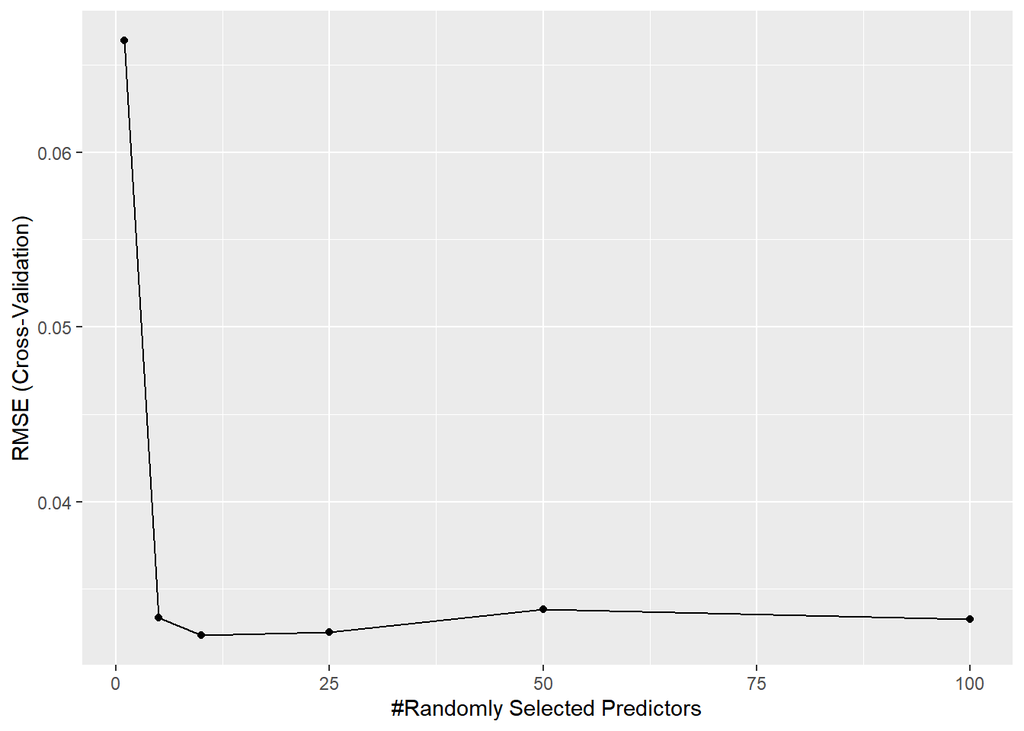

```r
control <- trainControl(method="cv", number = 5)
grid <- data.frame(mtry = c(1, 5, 10, 25, 50, 100))
col_index <- c(1,5,8,10)   # Colunas das 3 variáveis sem a renda , apenas a massa de renda

train_rf <-  train(train_set[, col_index], train_set$ind_se_norm,
                   method = "rf",
                   ntree = 150,
                   trControl = control,
                   tuneGrid = grid,
                   nSamp = 2000)
ggplot(train_rf)
```

```r
fit_rf <- randomForest(train_set[, col_index], train_set$ind_se_norm,
                       minNode = train_rf$bestTune$mtry)
y_rf <- predict(fit_rf, test_set[ ,col_index])
sqrt(mean((y_rf - test_set$ind_se_norm)^2))
```

```
## [1] 0.0841898
```

## Questões 3 e 4

Foi obtido a menor raiz quadrática média nesse modelo, que foi utilizada para calcular a sua qualidade apesar do modelo de regressão linear deu resultados bem bons quando utilizamos todas as variáveis para a regressão.

Tentei tambem deixar apenas as variáveis aparentemente mais úteis como critério de seleção, imaginando num set de dados maior poderia reduzir bastante o tempo de processamento do modelo. Imaginando um cenário de vida real, parece ser válido que apenas as variáveis de produção, renda e da PMCA alterem o consumo da indústria, dado que variações de temperatura por exemplo afetaria bem menos do que um consumo residencial que possuem geladeiras, chuveiros e etc.

Podemos explorar futuros valores diferentes nos parâemtros de random forests ou até outros valores de divisão de test e train set, porem para uma primeira análise parece que trouxe bons resultados, mesmo com “apenas” aproximadamente 100 registros para os dados com todas as variáveis. Lembrando tambem que o comportamento do consumo após 2012 foi diferente do que antes. Talvez outras variáveis externas possam ser estudadas para incorporar no modelo para uma melhor acurácia, porém acredito que para uma previsão de consumo da indústria os resultados parecem ser satisfatórios.